# An xDE prototype for `pr2foi`

David Smith

1/27/2022

## .

This is a prototype model for an xDE-based pr2foi.

## Model

### .

At the core, we use a mechanistic model to describe the relationship between the FoI and *Pf*PR by age. The model has several parts.

- The epidemiological states and state transitions.
- A model of fever, disease.
- A set of exposure tracking variables.

#### Parameters

The model has the following parameters:

- $h_a$ : The *happenings* rate, or FoI, as a function of age $a$. Here, we assume that $h_a$ depends on a population average FoI, which varies over time, $h(t)$, and an age-specific biting weight $w(a)$, so that $h_a = w(a) h(d+a)$.
- $\eta$ : risk of a primary malaria fever, per infection. Here, we assume $\eta$ is a function of the exposure (see below).
- $\rho$ : The case management fraction, the fraction of people with a primary malaria fever who treat and cure it. This does not consider malaria dynamics under partial compliance. Here, we set $\rho \approx 1/3$ as a baseline.
- $\delta$: The background treatment rate. We assume that people take antimalarial drugs at a background rate whether or not they are infected ($\delta \approx 1/365$d).
- $\sigma$: After treating malaria, there is a short period of chemoprotection. The duration of chemoprotection is $1/\sigma$ days ($1/\sigma \approx 15-20$d), depending on the drug).
- $r$ : The average duration of an untreated infection ($1/r \approx 100$d)

```r
makePar_PUXx = function(rho=1/3, deltaU=1/365, deltaX=1/180, sigma=1/20, r=1/120,
                            zeta_t=1/3, zeta_u=1/14, base=.1, s=.1, s1=1, N=1, k3=1/40,
                            mu0=1/180,mu1=1/3/365,mu2=1/7/365,b1=1,b3=10,s3=.1){
  par = list()
  par$rho=rho
  par$deltaU=deltaU
  par$deltaX=deltaX
  par$sigma=sigma
  par$r=r
  par$zeta_t = zeta_t
  par$zeta_u = zeta_u
  par$base = base
  par$s = s
  par$s1 = s1
  par$N = N
  par$k3 = k3
  par$mu0= mu0
  par$mu1=mu1
  par$mu2=mu2
  par$b1=b1
  par$b3=b3
  par$s3=s3
  class(par) <- "PUXx"
  return(par)
}
```

```r
modPar = makePar_PUXx()
```

#### Equations

- $P$: chemoprotected
- $U$: uninfected
- $X$: infected

$$\begin{equation}\begin{array}{rl}
\frac{dP}{da} &= \left(\eta \rho h_a + \delta\right) \left(1-P\right) - \sigma P \\
\frac{dU}{da} &= \sigma P - \left(h_a + \delta\right) U + r X \\
\frac{dX}{da} &= h_a \left( 1-\eta \rho \right) U -\left(r + h_a \eta \rho + \delta\right) X \\
\end{array}\end{equation}$$

### Age vs. FoI

We use the FoI family of functions developed as part of the `Memory` package.

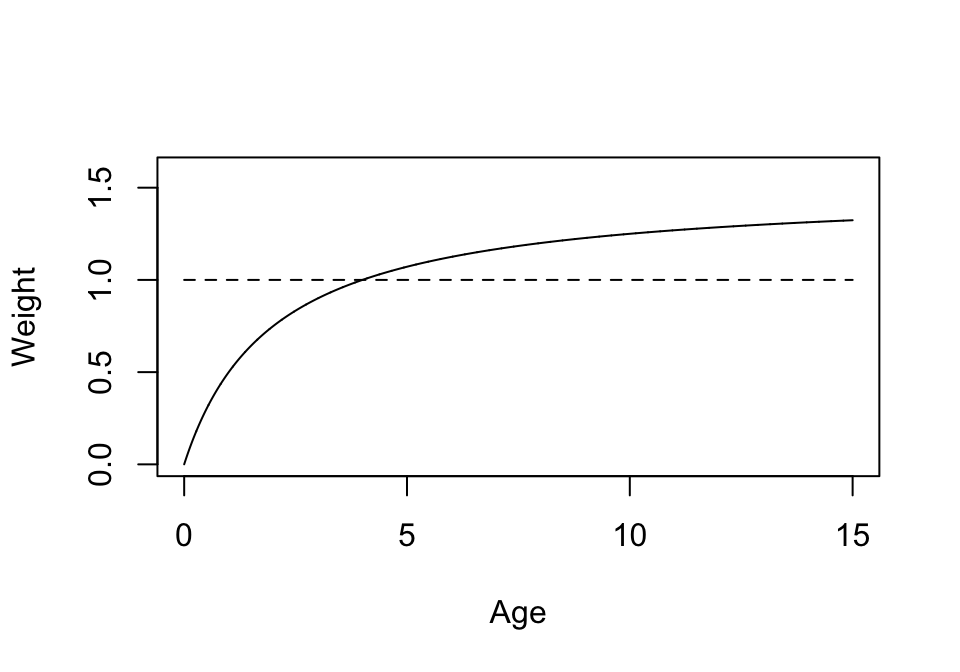

```r
aa = seq(0, 365*15, by =1)
plot(aa/365, ageFoI(aa,foiP4$agePar), type = "l", xlab = "Age", ylab= "Weight", ylim = c(0,1.6))
segments(0,1,15,1, lty=2)
```

### Memory Tracking

To model the effects of immunity, we present variables describing the amount of acquired immunity:

$$\begin{equation}\begin{array}{rl}
\frac{dV_0}{da} &= \mu_0 V_0\\
\frac{dV_1}{da} &= h \frac{s_1} {b_1 + s_1 h} (1-P) - \mu_1 V_1\\
\frac{dV_2}{da} &= h \frac{s_2} {b_2 + s_2 h} (1-P) - \mu_2 V_2\\
\frac{dV_3}{da} &= h \frac{s_3} {b_3 + s_3 h} (1-P) - \mu_3 V_3\\
\end{array}\end{equation}$$

### Primary Fever

**Variables**

- $F_t$: Treated primary fever
- $F_u$: Un-treated primary fever

$$\begin{equation}\begin{array}{rl}
\frac{dF_t}{da} &= h_a \eta \rho (1-P) - \zeta_t F_t \\
\frac{dF_u}{da} &= h_a \eta (1-\rho) (1-P) - \zeta_u F_u
\end{array}\end{equation}$$

### R-Code

Here, we let $\eta$ denote the probability of a primary fever.

```r
etaF = function(y, p){with(c(y,p),{
  exp(-s*(Vm+V0)/N)
})}
```

```r
nu = function(y,p){with(c(y,p),{
  r*exp(k3*(V1+V2))
})}
```

```r
sigmoid = function(x, md=12*365, shp=1/365){
  1/(1+exp(-shp*(x-md)))
}
```

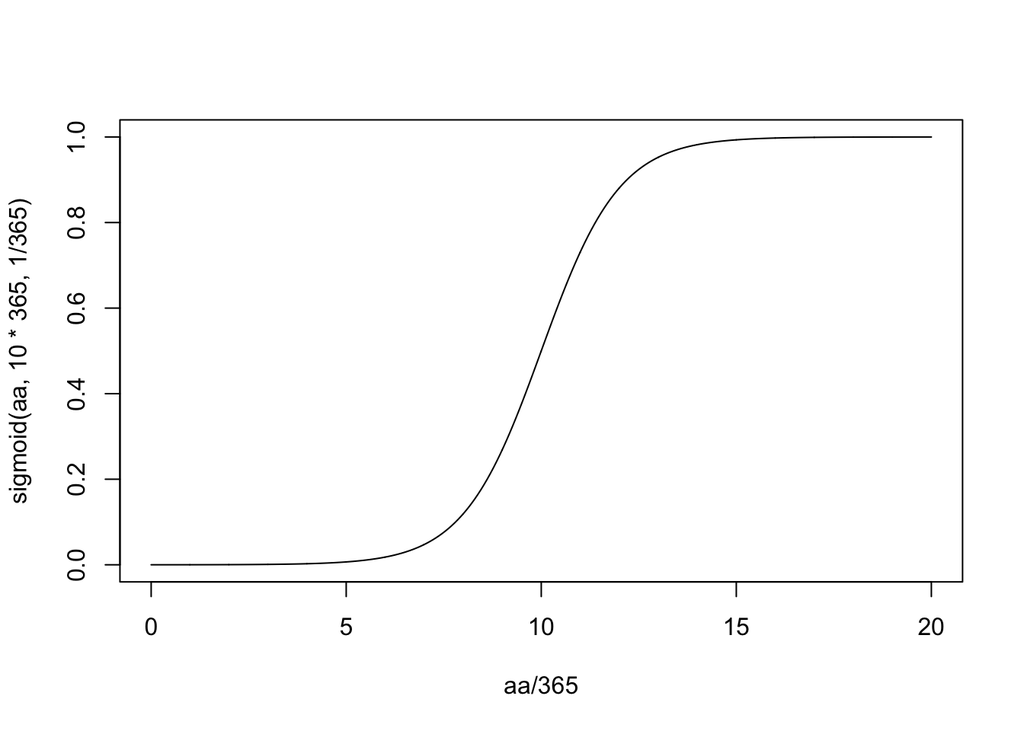

```r
aa = seq(0, 7300, length.out=2000)
plot(aa/365, sigmoid(aa, 10*365, 1/365), type = "l")
```

```r
diffPUXV = function(a,y,p,FoIpar){with(as.list(c(y,p)),{

  foi = FoI(a,FoIpar,tau,h)
  eta = etaF(y,p)

  # State Variables
  dP  = (foi*rho*eta)*(1-P) + deltaU*U + (deltaU+deltaX)*X - sigma*P
  dU  = sigma*P - (foi+deltaU)*U + r*X
  dX  = foi*(1-eta*rho)*U - (r + foi*eta*rho+deltaU+deltaX)*X
  dx  = foi*(1-eta*rho)*U - (nu(y,p)+foi*eta*rho+deltaU+deltaX)*x

  # Fever
  dFt = rho*(eta*foi)*(1-P)-zeta_t*Ft
  dFu = (1-rho)*(eta*foi)*(1-P)-zeta_u*Fu

  # Exposure Tracking
  dVm = -mu0*Vm
  dV0 = h*(1-P)
  dV1 = h*(1-P) - mu1*V1
  dV2 = foi*sigmoid(a) -mu2*V2

  list(c(dP, dU, dX, dx, dFt, dFu, dVm, dV0, dV1, dV2))
})}
```

```r
solvePUXV = function(h, modPar,
                     FoIpar,
                     #change values for rho, delta
                     rho=NULL,deltaX=NULL,deltaU=NULL,
                     #the birth cohort
                     tau=0,
                     Tmax=365*25){
  tms = 0:Tmax
  modPar$h=h
  if(!is.null(rho)) modPar$rho=rho
  if(!is.null(deltaX)) modPar$deltaX=deltaX
  if(!is.null(deltaU)) modPar$deltaU=deltaU
  modPar$tau = tau
  data.frame(lsode(c(P=0, U=1, X=0, x=0, Ft=0, Fu=0, Vm=10, V0=0, V1=0, V2=0), times=tms, diffPUXV, modPar, FoIpar=FoIpar))
}
```

## Plots

### 1

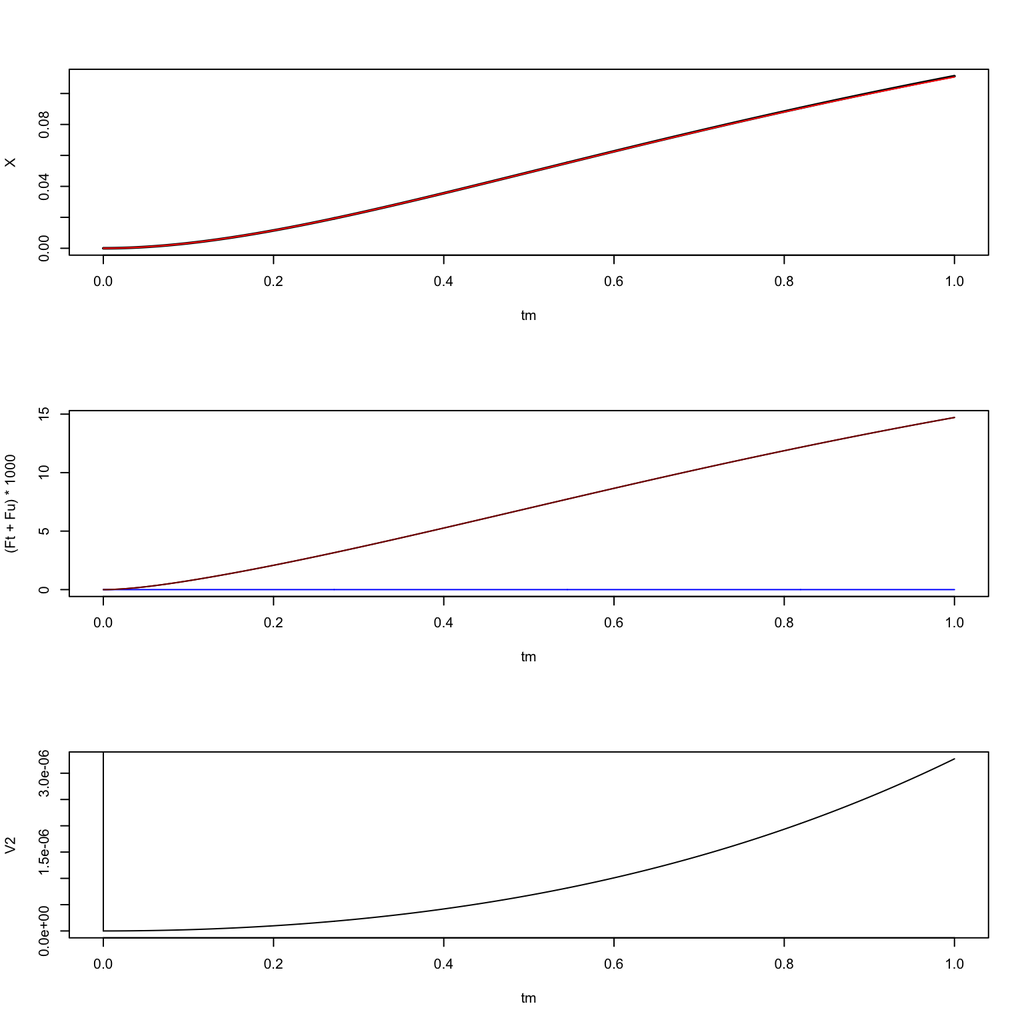

## pr2foi.PUXx

```r
foi2pr.PUXx= function(h, a, modPar, lout=200){
  tms = c(0:max(a))
  modPar$h=h
  modPar$tau=0
  xa = data.frame(lsode(c(P=0, U=1, X=0, x=0, Ft=0, Fu=0, Vm=10, V0=0, V1=0, V2=0), times=tms, diffPUXV, modPar, FoIpar=foiP4))$x
  ix = findInterval(a, tms)
  xa[ix]
}
```

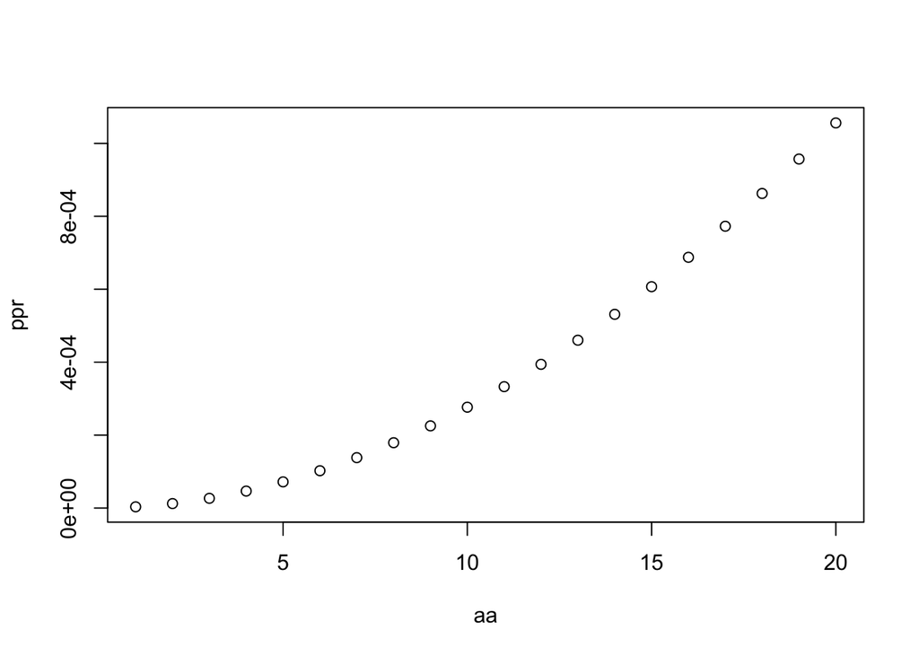

```r
aa = c(1:20)
ppr = foi2pr.PUXx(1/365, aa, modPar)
plot(aa, ppr)
```